# Classify Genres and Emotions in Songs Using Deep Learning

## Description:

The goal of this lab is to recognize the genre and extract the emotions from spectrograms of music songs. We are given 2 datasets:

- Free Music Archive (FMA) genre that contains 3834 samples from 20 music genres.
- Multitask music dataset that contains 1497 samples with labels about the emotions such as valence, energy and danceability.

All samples came from spectrograms, that have been extracted from clips of 30 seconds from different songs. We will analyze the spectrograms using deep learning architectures such as Recurrent Neural Networks and Convolutional Neural Networks. The exercise is separated in 5 parts:

- Data analysis and familiarize with spectrograms.
- Implement classifiers about the music genre using the FMA dataset.
- Implement regression models for predicting valence, energy and danceability.
- Use of modern training techniques, such as transfer and multitask learning, to improve the previous results.
- Submit results in the Kaggle competition of the exercise (optional).

```python
# Import necessary libraries
import numpy as np
import copy
import re
import os
import pandas as pd
import random
import matplotlib.pyplot as plt

# Sklearn
from sklearn.metrics import f1_score, accuracy_score, recall_score, classification_report
from sklearn.preprocessing import LabelEncoder

# Pytorch
import torch
from torch import nn
from torch import optim
from torch.utils.data import Dataset
from torch.utils.data import SubsetRandomSampler, DataLoader
import torch.nn.functional as F
from torchvision import transforms
import torchvision.models as models

# Scipy
from scipy.stats import spearmanr

# Other
from IPython.display import Image
```

## Data Loading

In this section, all the code for loading and manipulating the 2 datasets is available. Some parts are the same with the prepare_lab.

```python
# Combine similar classes and remove underrepresented classes.

class_mapping = {
    'Rock': 'Rock',
    'Psych-Rock': 'Rock',
    'Indie-Rock': None,
    'Post-Rock': 'Rock',
    'Psych-Folk': 'Folk',
    'Folk': 'Folk',
    'Metal': 'Metal',
    'Punk': 'Metal',
    'Post-Punk': None,
    'Trip-Hop': 'Trip-Hop',
    'Pop': 'Pop',
    'Electronic': 'Electronic',
    'Hip-Hop': 'Hip-Hop',
    'Classical': 'Classical',
    'Blues': 'Blues',
    'Chiptune': 'Electronic',
    'Jazz': 'Jazz',
    'Soundtrack': None,
    'International': None,
    'Old-Time': None
}
```

```python
# Define a function that splits a dataset in train and validation set.

def torch_train_val_split(dataset, batch_train, batch_eval, val_size=.2, shuffle=True, seed=None):
    # Creating data indices for training and validation splits:
    dataset_size = len(dataset)
    indices = list(range(dataset_size))
    val_split = int(np.floor(val_size * dataset_size))
    if shuffle:
        np.random.seed(seed)
        np.random.shuffle(indices)
    # Rearrange train and validation set
    train_indices = indices[val_split:]
    val_indices = indices[:val_split]

    # Creating PT data samplers and loaders:
    train_sampler = SubsetRandomSampler(train_indices)
    val_sampler = SubsetRandomSampler(val_indices)

    train_loader = DataLoader(dataset,
                              batch_size=batch_train,
                              sampler=train_sampler)
    val_loader = DataLoader(dataset,
                            batch_size=batch_eval,
                            sampler=val_sampler)
    return train_loader, val_loader
```

```python
# Define some useful functions for loading spectrograms and chromagrams

def read_fused_spectrogram(spectrogram_file):
    spectrogram = np.load(spectrogram_file)
    return spectrogram.T


def read_mel_spectrogram(spectrogram_file):
    spectrogram = np.load(spectrogram_file)[:128]
    return spectrogram.T


def read_chromagram(spectrogram_file):
    spectrogram = np.load(spectrogram_file)[128:]
    return spectrogram.T
```

```python
# Define an encoder for the labels

class LabelTransformer(LabelEncoder):
    def inverse(self, y):
        try:
            return super(LabelTransformer, self).inverse_transform(y)
        except:
            return super(LabelTransformer, self).inverse_transform([y])

    def transform(self, y):
        try:
            return super(LabelTransformer, self).transform(y)
        except:
            return super(LabelTransformer, self).transform([y])
```

```python
# Define a PaddingTransformer in order to convert all input sequences to the same length

class PaddingTransform(object):
    def __init__(self, max_length, padding_value=0):
        self.max_length = max_length
        self.padding_value = padding_value

    def __call__(self, s):
        if len(s) == self.max_length:
            return s

        if len(s) > self.max_length:
            return s[:self.max_length]

        if len(s) < self.max_length:
            s1 = copy.deepcopy(s)
            pad = np.zeros((self.max_length - s.shape[0], s.shape[1]), dtype=np.float32)
            s1 = np.vstack((s1, pad))
            return s1
```

```python
# Define useful parameters that are the same for all the models.

num_mel = 128
num_chroma = 12
n_classes = 10
```

- Define a Pytorch dataset for the 1st dataset.

```python
class SpectrogramDataset(Dataset):
    def __init__(self, path, class_mapping=None, train=True, max_length=-1, read_spec_fn=read_fused_spectrogram):
        t = 'train' if train else 'test'
        p = os.path.join(path, t)
        self.index = os.path.join(path, "{}_labels.txt".format(t))
        self.files, labels = self.get_files_labels(self.index, class_mapping)
        self.feats = [read_spec_fn(os.path.join(p, f)) for f in self.files]
        self.feat_dim = self.feats[0].shape[1]
        self.lengths = [len(i) for i in self.feats]
        self.max_length = max(self.lengths) if max_length <= 0 else max_length
        self.zero_pad_and_stack = PaddingTransform(self.max_length)
        self.label_transformer = LabelTransformer()
        if isinstance(labels, (list, tuple)):
            self.labels = np.array(self.label_transformer.fit_transform(labels)).astype('int64')

    def get_files_labels(self, txt, class_mapping):
        with open(txt, 'r') as fd:
            lines = [l.rstrip().split('\t') for l in fd.readlines()[1:]]
        files, labels = [], []
        for l in lines:
            label = l[1]
            if class_mapping:
                label = class_mapping[l[1]]
            if not label:
                continue
            # Kaggle automatically unzips the npy.gz format so this hack is needed
            _id = l[0].split('.')[0]
            npy_file = '{}.fused.full.npy'.format(_id)
            files.append(npy_file)
            labels.append(label)
        return files, labels


    def __getitem__(self, item):
        # Return a tuple in the form (padded_feats, label, length)
        l = min(self.lengths[item], self.max_length)
        return self.zero_pad_and_stack(self.feats[item]), self.labels[item], l

    def __len__(self):
        return len(self.labels)
```

- Load mel spectrograms.

```python
mel_specs = SpectrogramDataset(
         '../input/patreco3-multitask-affective-music/data/fma_genre_spectrograms/',
         train=True,
         class_mapping=class_mapping,
         max_length=-1,
         read_spec_fn=read_mel_spectrogram)

train_loader_mel, val_loader_mel = torch_train_val_split(mel_specs, 32 ,32, val_size=.33)
```

```python
print("Shape of a train example in SpectrogramDataset: ")
print(mel_specs[1][0].shape)
```

```
Shape of a train example in SpectrogramDataset:
(1293, 128)
```

We should pad the test set, so as to have the same shape with the train dataset (in order to use them in the following CNN).

```python
test_mel = SpectrogramDataset(
         '../input/patreco3-multitask-affective-music/data/fma_genre_spectrograms/',
         train=False,
         class_mapping=class_mapping,
         max_length=1293,
         read_spec_fn=read_mel_spectrogram)

test_loader_mel = DataLoader(test_mel, batch_size=32)
```

### Step 7: 2D CNN

Antother way of contructing a model for analyzing speech singnals is to see the spectrogram as an image and use a Convolutional Neural Network.

- [Here](https://cs.stanford.edu/people/karpathy/convnetjs/) we can train simple Convolutional Networks and check their internal functions by displaying the activations of each layer without programming cost. We will train a CNN in MNIST and comment on the functions.

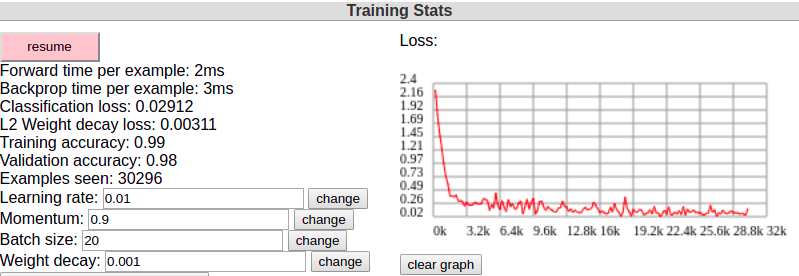

```python
Image("../input/images/convnetjs_1.png")
```

The dataset is fairly easy and the accuracy for the validation set is very high.

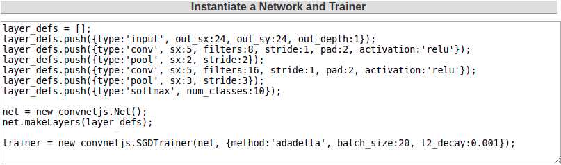

```python
Image("../input/images/convnetjs_2.png")
```

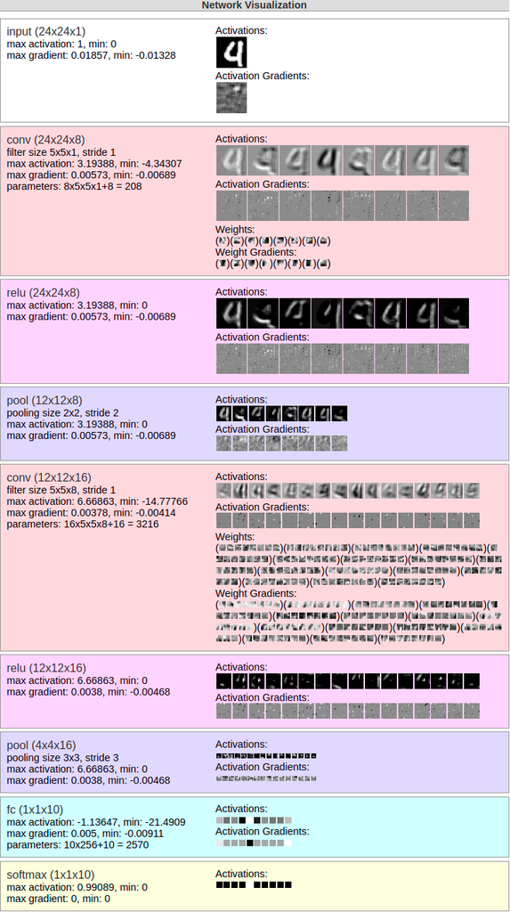

```python
Image("../input/images/convnetjs_3.png")
```

In each layer, each neuron learns a part of the corresponding digit.

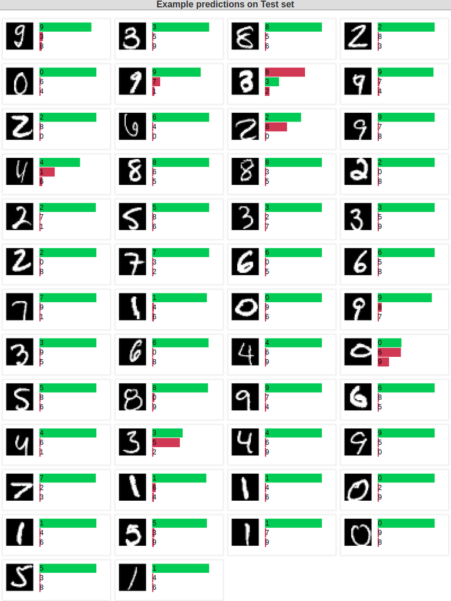

```python
Image("../input/images/convnetjs_4.png")
```

The only wrong prediction on the test set is in an image that even a person may predict wrong since it is not clearly written.

- Define a 2D CNN with 4 layers. Each layer implements the following operations:
  - 2D convclution: The purpose of this step is to extract features from the input image. Convolution preserves the spatial relationship between pixels by learning image features using small squares of input data
  - Batch normalization: Speeds up learning.
  - ReLU activation: Using ReLU, we introduce non-linearity in our ConvNet, since most of the real-world data we would want our ConvNet to learn would be non-linear.
  - Max pooling: Reduces the dimensionality of each feature map but retains the most important information.

```python
# Define a function that trains the model for an epoch.

def train_dataset(_epoch, dataloader, model, loss_function, optimizer):
    # IMPORTANT: switch to train mode
    # Εnable regularization layers, such as Dropout
    model.train()
    running_loss = 0.0

    # Οbtain the model's device ID
    device = next(model.parameters()).device

    for index, batch in enumerate(dataloader, 1):
        # Get the inputs (batch)
        inputs, labels, lengths = batch

        # Move the batch tensors to the right device
        inputs = inputs.to(device)
        labels = labels.to(device)

        # Step 1 - zero the gradients
        # Remember that PyTorch accumulates gradients.
        # We need to clear them out before each batch!
        optimizer.zero_grad()

        # Step 2 - forward pass: y' = model(x)
        y_preds = model(inputs, lengths)

        # Step 3 - compute loss: L = loss_function(y, y')
        loss = loss_function(y_preds, labels)

        # Step 4 - backward pass: compute gradient wrt model parameters
        loss.backward()

        # Step 5 - update weights
        optimizer.step()

        # Accumulate loss in a variable.
        running_loss += loss.data.item()

    return running_loss / index
```

```python
# Define a function that evaluates the model in an epoch.
def eval_dataset(dataloader, model, loss_function):
    # IMPORTANT: switch to eval mode
    # Disable regularization layers, such as Dropout
    model.eval()
    running_loss = 0.0

    y_pred = []  # the predicted labels
    y = []  # the gold labels

    # Obtain the model's device ID
    device = next(model.parameters()).device

    # IMPORTANT: in evaluation mode, we don't want to keep the gradients
    # so we do everything under torch.no_grad()

    with torch.no_grad():
        for index, batch in enumerate(dataloader, 1):
            # Get the inputs (batch)
            inputs, labels, lengths = batch

            # Step 1 - move the batch tensors to the right device
            inputs = inputs.to(device)
            labels = labels.to(device)

            # Step 2 - forward pass: y' = model(x)
            y_preds = model(inputs, lengths)  # EX9

            # Step 3 - compute loss: L = loss_function(y, y')
            # We compute the loss only for inspection (compare train/test loss)
            # because we do not actually backpropagate in test time
            loss = loss_function(y_preds, labels)

            # Step 4 - make predictions (class = argmax of posteriors)
            y_preds_arg = torch.argmax(y_preds, dim=1)

            # Step 5 - collect the predictions, gold labels and batch loss
            y_pred.append(y_preds_arg.cpu().numpy())
            y.append(labels.cpu().numpy())

            # Accumulate loss in a variable
            running_loss += loss.data.item()

    return running_loss / index, (y, y_pred)
```

```python
# Define the CNN architecture

class ConvNet(nn.Module):
    def __init__(self):
        super(ConvNet, self).__init__()
        self.conv1 = nn.Conv2d(1, 3, 5)
        self.conv1_bn = nn.BatchNorm2d(3)
        self.pool1 = nn.MaxPool2d(2, 2)

        self.conv2 = nn.Conv2d(3, 6, 5)
        self.conv2_bn = nn.BatchNorm2d(6)
        self.pool2 = nn.MaxPool2d(2, 2)

        self.conv3 = nn.Conv2d(6, 8, 3)
        self.conv3_bn = nn.BatchNorm2d(8)
        self.pool3 = nn.MaxPool2d(2, 2)

        self.conv4 = nn.Conv2d(8, 12, 3)
        self.conv4_bn = nn.BatchNorm2d(12)
        self.pool4 = nn.MaxPool2d(2, 2)

        self.fc1 = nn.Linear(4680, 128)

        self.fc2 = nn.Linear(128, 10)

    def forward(self, x, lengths):
        x = x.view(x.size(0), 1, x.size(1), x.size(2))

        x = self.pool1(F.relu( self.conv1_bn(self.conv1(x))))
        x = self.pool2(F.relu( self.conv2_bn(self.conv2(x))))
        x = self.pool3(F.relu( self.conv3_bn(self.conv3(x))))
        x = self.pool4(F.relu( self.conv4_bn(self.conv4(x))))

        x = x.view(x.size(0), -1)
        x = F.relu(self.fc1(x))
        x = self.fc2(x)
        return x
```

Train the model in the mel spectrograms.

```python
EPOCHS = 15
model = ConvNet()
DEVICE = torch.device("cuda" if torch.cuda.is_available() else "cpu")
model.double()
model.to(DEVICE)
loss_function = nn.CrossEntropyLoss().to(DEVICE)
optimizer = torch.optim.Adam(model.parameters(), lr=0.001, weight_decay=1e-5)
n_epochs_stop = 4
min_val_loss = 1000
epochs_no_improve = 0

for epoch in range(EPOCHS):
    # Train the model for one epoch
    train_dataset(epoch, train_loader_mel, model, loss_function, optimizer)

    # Evaluate the performance of the model, on both data sets
    train_loss, (y_train_gold, y_train_pred) = eval_dataset(train_loader_mel, model, loss_function)

    val_loss, (y_val_gold, y_val_pred) = eval_dataset(val_loader_mel, model, loss_function)

    if val_loss < min_val_loss:
        # Save the model
        torch.save(model, "./mel_cnn")
        epochs_no_improve = 0
        min_val_loss = val_loss
    else:
        epochs_no_improve += 1

    if epochs_no_improve == n_epochs_stop:
        print('Early stopping!')
        break

    y_train_true = np.concatenate( y_train_gold, axis=0 )
    y_val_true = np.concatenate( y_val_gold, axis=0 )
    y_train_pred = np.concatenate( y_train_pred, axis=0 )
    y_val_pred = np.concatenate( y_val_pred, axis=0 )
    print("Epoch %d " %epoch)
    print("Train loss: %f" %train_loss)
    print("Validation loss: %f" %val_loss)
    print("Accuracy for train:" , accuracy_score(y_train_true, y_train_pred))
    print("Accuracy for validation:" , accuracy_score(y_val_true, y_val_pred))
    print()

# Save the model for future evaluation
torch.save(model, './mel_cnn')
```

```
Epoch 0
Train loss: 1.996303
Validation loss: 2.002178
Accuracy for train: 0.28932038834951457
Accuracy for validation: 0.25921052631578945

Epoch 1
Train loss: 1.924852
Validation loss: 1.920780
Accuracy for train: 0.32233009708737864
Accuracy for validation: 0.3131578947368421

Epoch 2
Train loss: 1.863517
Validation loss: 1.895983
Accuracy for train: 0.3042071197411003
Accuracy for validation: 0.2618421052631579

Epoch 3
Train loss: 1.711279
Validation loss: 1.828779
Accuracy for train: 0.3896440129449838
Accuracy for validation: 0.3381578947368421

Epoch 4
Train loss: 1.520410
Validation loss: 1.762604
Accuracy for train: 0.4524271844660194
Accuracy for validation: 0.36447368421052634

Epoch 5
Train loss: 1.303635
Validation loss: 1.810773
Accuracy for train: 0.5482200647249191
Accuracy for validation: 0.3763157894736842

Epoch 6
Train loss: 1.153272
Validation loss: 1.817394
Accuracy for train: 0.6213592233009708
Accuracy for validation: 0.36973684210526314

Epoch 7
Train loss: 1.072339
Validation loss: 1.935727
Accuracy for train: 0.6187702265372168
Accuracy for validation: 0.3671052631578947

Early stopping!
```

```python
# Load the model
model = torch.load('./mel_cnn')
model.eval()
```

```
ConvNet(
  (conv1): Conv2d(1, 3, kernel_size=(5, 5), stride=(1, 1))
  (conv1_bn): BatchNorm2d(3, eps=1e-05, momentum=0.1, affine=True, track_running_stats=True)
  (pool1): MaxPool2d(kernel_size=2, stride=2, padding=0, dilation=1, ceil_mode=False)
  (conv2): Conv2d(3, 6, kernel_size=(5, 5), stride=(1, 1))
  (conv2_bn): BatchNorm2d(6, eps=1e-05, momentum=0.1, affine=True, track_running_stats=True)
  (pool2): MaxPool2d(kernel_size=2, stride=2, padding=0, dilation=1, ceil_mode=False)
  (conv3): Conv2d(6, 8, kernel_size=(3, 3), stride=(1, 1))
  (conv3_bn): BatchNorm2d(8, eps=1e-05, momentum=0.1, affine=True, track_running_stats=True)
  (pool3): MaxPool2d(kernel_size=2, stride=2, padding=0, dilation=1, ceil_mode=False)
  (conv4): Conv2d(8, 12, kernel_size=(3, 3), stride=(1, 1))
  (conv4_bn): BatchNorm2d(12, eps=1e-05, momentum=0.1, affine=True, track_running_stats=True)
  (pool4): MaxPool2d(kernel_size=2, stride=2, padding=0, dilation=1, ceil_mode=False)
  (fc1): Linear(in_features=4680, out_features=128, bias=True)
  (fc2): Linear(in_features=128, out_features=10, bias=True)
)
```

Evaluate the cnn model in the test set

```python
test_loss, (y_test_gold, y_test_pred) = eval_dataset(test_loader_mel, model, loss_function)

y_test_true = np.concatenate( y_test_gold, axis=0 )
y_test_pred = np.concatenate( y_test_pred, axis=0 )
print("Test loss: %f" %test_loss)
print("Accuracy for test:" , accuracy_score(y_test_true, y_test_pred))
print()
```

```
Test loss: 1.916079
Accuracy for test: 0.33217391304347826
```

## Step 8: Sentiment prediction with regression

Now, we will use the multitask dataset.

```python
# Define a Pytorch dataset for the Multitask dataset

class MultitaskDataset(Dataset):
    def __init__(self, path, max_length=-1, read_spec_fn=read_fused_spectrogram, label_type='energy'):
        p = os.path.join(path, 'train')
        self.label_type = label_type
        self.index = os.path.join(path, "train_labels.txt")
        self.files, labels = self.get_files_labels(self.index)
        self.feats = [read_spec_fn(os.path.join(p, f)) for f in self.files]
        self.feat_dim = self.feats[0].shape[1]
        self.lengths = [len(i) for i in self.feats]
        self.max_length = max(self.lengths) if max_length <= 0 else max_length
        self.zero_pad_and_stack = PaddingTransform(self.max_length)
        if isinstance(labels, (list, tuple)):
            self.labels = np.array(labels)

    def get_files_labels(self, txt):
        with open(txt, 'r') as fd:
            lines = [l.split(',') for l in fd.readlines()[1:]]
        files, labels = [], []
        for l in lines:
            if self.label_type == 'valence':
                labels.append(float(l[1]))
            elif self.label_type == 'energy':
                labels.append(float(l[2]))
            elif self.label_type == 'danceability':
                labels.append(float(l[3].strip("\n")))
            else:
                labels.append([float(l[1]), float(l[2]), float(l[3].strip("\n"))])
            # Kaggle automatically unzips the npy.gz format so this hack is needed
            _id = l[0]
            npy_file = '{}.fused.full.npy'.format(_id)
            files.append(npy_file)
        return files, labels


    def __getitem__(self, item):
        # Return a tuple in the form (padded_feats, valence, energy, danceability, length)
        l = min(self.lengths[item], self.max_length)
        return self.zero_pad_and_stack(self.feats[item]), self.labels[item], l

    def __len__(self):
        return len(self.labels)
```

- Load mulstitask dataset with certain padding in order to fit in the previous CNN.

```python
specs_multi_valence = MultitaskDataset(
         '../input/patreco3-multitask-affective-music/data/multitask_dataset/',
         max_length=1293,
         label_type='valence',
         read_spec_fn=read_mel_spectrogram)

train_loader_valence , val_loader_valence = torch_train_val_split(specs_multi_valence, 32 ,32, val_size=.33)
```

```python
specs_multi_energy = MultitaskDataset(
         '../input/patreco3-multitask-affective-music/data/multitask_dataset/',
         max_length=1293,
         label_type='energy',
         read_spec_fn=read_mel_spectrogram)

train_loader_energy, val_loader_energy = torch_train_val_split(specs_multi_energy, 32 ,32, val_size=.33)
```

```python
specs_multi_danceability = MultitaskDataset(
         '../input/patreco3-multitask-affective-music/data/multitask_dataset/',
         max_length=1293,
         label_type='danceability',
         read_spec_fn=read_mel_spectrogram)

train_loader_danceability, val_loader_danceability = torch_train_val_split(specs_multi_danceability, 32 ,32, val_size=.33)
```

```python
print(specs_multi_valence[0][0].shape)
print(specs_multi_energy[0][0].shape)
print(specs_multi_danceability[0][0].shape)
```

```
(1293, 128)
(1293, 128)
(1293, 128)
```

- Load beat mulstitask dataset for the LSTM.

```python
beat_specs_multi_valence = MultitaskDataset(
         '../input/patreco3-multitask-affective-music/data/multitask_dataset_beat/',
         max_length=-1,
         label_type='valence',
         read_spec_fn=read_mel_spectrogram)

beat_train_loader_valence , beat_val_loader_valence = torch_train_val_split(beat_specs_multi_valence, 32 ,32, val_size=.33)
```

```python
beat_specs_multi_energy = MultitaskDataset(
         '../input/patreco3-multitask-affective-music/data/multitask_dataset_beat/',
         max_length=-1,
         label_type='energy',
         read_spec_fn=read_mel_spectrogram)

beat_train_loader_energy, beat_val_loader_energy = torch_train_val_split(beat_specs_multi_energy, 32 ,32, val_size=.33)
```

```python
beat_specs_multi_danceability = MultitaskDataset(
         '../input/patreco3-multitask-affective-music/data/multitask_dataset_beat/',
         max_length=-1,
         label_type='danceability',
         read_spec_fn=read_mel_spectrogram)

beat_train_loader_danceability, beat_val_loader_danceability = torch_train_val_split(beat_specs_multi_danceability, 32 ,32, val_size=.33)
```

```python
print(beat_specs_multi_valence[0][0].shape)
print(beat_specs_multi_energy[0][0].shape)
print(beat_specs_multi_danceability[0][0].shape)
```

```
(104, 128)
(104, 128)
(104, 128)
```

- Define the LSTM of Step 5 (prepare_lab) and train the beat mel multitask dataset.

```python
class BasicLSTM(nn.Module):
    def __init__(self, input_dim, rnn_size, output_dim, num_layers, bidirectional=False, dropout=0):
        super(BasicLSTM, self).__init__()
        self.bidirectional = bidirectional
        self.rnn_size = rnn_size
        self.feature_size = rnn_size * 2 if self.bidirectional else rnn_size
        self.num_layers = num_layers
        self.dropout = dropout

        # Initialize the LSTM, Dropout, Output layers

        self.lstm = nn.LSTM(input_dim, self.rnn_size, self.num_layers, bidirectional=self.bidirectional, batch_first=True, dropout=self.dropout)
        self.linear = nn.Linear(self.feature_size, output_dim)

    def forward(self, x, lengths):
        """
            x : 3D numpy array of dimension N x L x D
                N: batch index
                L: sequence index
                D: feature index

            lengths: N x 1
         """

        # Obtain the model's device ID
        DEVICE = torch.device("cuda" if torch.cuda.is_available() else "cpu")


        # You must have all of the outputs of the LSTM, but you need only the last one (that does not exceed the sequence length)
        # To get it use the last_timestep method
        # Then pass it through the remaining network

        if self.bidirectional:
            h0 = torch.zeros(self.num_layers*2, x.size(0), self.rnn_size).double().to(DEVICE)
            c0 = torch.zeros(self.num_layers*2, x.size(0), self.rnn_size).double().to(DEVICE)
        else:
            h0 = torch.zeros(self.num_layers, x.size(0), self.rnn_size).double().to(DEVICE)
            c0 = torch.zeros(self.num_layers, x.size(0), self.rnn_size).double().to(DEVICE)

        # Forward propagate LSTM
        lstm_out, _ = self.lstm(x, (h0, c0))

        # Forward propagate Linear
        last_outputs = self.linear(self.last_timestep(lstm_out, lengths, self.bidirectional))
        return last_outputs.view(-1)

    def last_timestep(self, outputs, lengths, bidirectional=False):
        """
            Returns the last output of the LSTM taking into account the zero padding
        """
        if bidirectional:
            forward, backward = self.split_directions(outputs)
            last_forward = self.last_by_index(forward, lengths)
            last_backward = backward[:, 0, :]
            # Concatenate and return - maybe add more functionalities like average
            return torch.cat((last_forward, last_backward), dim=-1)

        else:
            return self.last_by_index(outputs, lengths)

    @staticmethod
    def split_directions(outputs):
        direction_size = int(outputs.size(-1) / 2)
        forward = outputs[:, :, :direction_size]
        backward = outputs[:, :, direction_size:]
        return forward, backward

    @staticmethod
    def last_by_index(outputs, lengths):
        # Obtain the model's device ID
        DEVICE = torch.device("cuda" if torch.cuda.is_available() else "cpu")

        # Index of the last output for each sequence.
        idx = (lengths - 1).view(-1, 1).expand(outputs.size(0),
                                               outputs.size(2)).unsqueeze(1).to(DEVICE)
        return outputs.gather(1, idx).squeeze()
```

```python
# Define train function for regression.

def train_dataset_regression(_epoch, dataloader, model, loss_function, optimizer):
    # IMPORTANT: switch to train mode
    # Εnable regularization layers, such as Dropout
    model.train()
    running_loss = 0.0

    # Οbtain the model's device ID
    device = next(model.parameters()).device

    for index, batch in enumerate(dataloader, 1):
        # Get the inputs (batch)
        inputs, labels, lengths = batch

        # Move the batch tensors to the right device
        inputs = inputs.to(device)
        labels = labels.to(device)


        # Step 1 - zero the gradients
        # Remember that PyTorch accumulates gradients.
        # We need to clear them out before each batch!
        optimizer.zero_grad()

        # Step 2 - forward pass: y' = model(x)
        y_preds = model(inputs, lengths)

        # Step 3 - compute loss: L = loss_function(y, y')
        loss = loss_function(y_preds, labels.double())

        # Step 4 - backward pass: compute gradient wrt model parameters
        loss.backward()

        # Step 5 - update weights
        optimizer.step()

        # Accumulate loss in a variable.
        running_loss += loss.data.item()

    return running_loss / index
```

```python
# Define evaluation function for regression.

def eval_dataset_regression(dataloader, model, loss_function):
    # IMPORTANT: switch to eval mode
    # Disable regularization layers, such as Dropout
    model.eval()
    running_loss = 0.0

    y_pred = []  # the predicted labels
    y = []  # the gold labels

    # Obtain the model's device ID
    device = next(model.parameters()).device

    # IMPORTANT: in evaluation mode, we don't want to keep the gradients
    # so we do everything under torch.no_grad()

    with torch.no_grad():
        for index, batch in enumerate(dataloader, 1):
            # Get the inputs (batch)
            inputs, labels, lengths = batch

            # Step 1 - move the batch tensors to the right device
            inputs = inputs.to(device)
            labels = labels.to(device)

            # Step 2 - forward pass: y' = model(x)
            y_preds = model(inputs, lengths)  # EX9

            # Step 3 - compute loss: L = loss_function(y, y')
            # We compute the loss only for inspection (compare train/test loss)
            # because we do not actually backpropagate in test time
            loss = loss_function(y_preds, labels.double())

            # Step 5 - collect the predictions, gold labels and batch loss
            y_pred.append(y_preds.cpu().numpy())
            y.append(labels.cpu().numpy())

            # Accumulate loss in a variable
            running_loss += loss.data.item()

    return running_loss / index, (y, y_pred)
```

In order to train the 2nd dataset in the models that we have defined, we should change the loss function for regression. We will use mean squared error.

- Training for valence in LSTM.

```python
RNN_SIZE = 32
EPOCHS = 20

model = BasicLSTM(num_mel, RNN_SIZE, 1, 1, bidirectional=True)
DEVICE = torch.device("cuda" if torch.cuda.is_available() else "cpu")
model.double()
model.to(DEVICE)
loss_function = nn.MSELoss().to(DEVICE)
optimizer = torch.optim.Adam(model.parameters(), lr=0.001)

for epoch in range(EPOCHS):
    # Train the model for one epoch
    train_dataset_regression(epoch, beat_train_loader_valence, model, loss_function, optimizer)

    # Evaluate the performance of the model, on both data sets
    train_loss, _ = eval_dataset_regression(beat_train_loader_valence, model, loss_function)

    val_loss, _ = eval_dataset_regression(beat_val_loader_valence, model, loss_function)

    if epoch%(5) == 0:
        print("Epoch %d " %epoch)
        print("Train loss: %f" %train_loss)
        print("Validation loss: %f" %val_loss)
        print()

torch.save(model, './multitask_lstm_valence')
```

```
Epoch 0
Train loss: 0.065562
Validation loss: 0.066166

Epoch 5
Train loss: 0.064780
Validation loss: 0.066452

Epoch 10
Train loss: 0.064573
Validation loss: 0.065283

Epoch 15
Train loss: 0.066915
Validation loss: 0.066869
```

```python
model = torch.load('./multitask_lstm_valence')

test_loss, (y_test_gold, y_test_pred) = eval_dataset_regression(beat_val_loader_valence, model, loss_function)

y_test_true = np.concatenate( y_test_gold, axis=0 )
y_test_pred = np.concatenate( y_test_pred, axis=0 )
print("Spearman: %f" %spearmanr(y_test_true, y_test_pred)[0])
print()
```

```
Spearman: 0.046428
```

- Training for energy in LSTM.

```python
RNN_SIZE = 32
EPOCHS = 20

model = BasicLSTM(num_mel, RNN_SIZE, 1, 1, bidirectional=True)
DEVICE = torch.device("cuda" if torch.cuda.is_available() else "cpu")
model.double()
model.to(DEVICE)
loss_function = nn.MSELoss().to(DEVICE)
optimizer = torch.optim.Adam(model.parameters(), lr=0.001)

for epoch in range(EPOCHS):
    # Train the model for one epoch
    train_dataset_regression(epoch, beat_train_loader_energy, model, loss_function, optimizer)

    # Evaluate the performance of the model, on both data sets
    train_loss, _ = eval_dataset_regression(beat_train_loader_energy, model, loss_function)

    val_loss, _ = eval_dataset_regression(beat_val_loader_energy, model, loss_function)

    if epoch%(5) == 0:
        print("Epoch %d " %epoch)
        print("Train loss: %f" %train_loss)
        print("Validation loss: %f" %val_loss)
        print()

torch.save(model, './multitask_lstm_energy')
```

```
Epoch 0
Train loss: 0.059705
Validation loss: 0.074615

Epoch 5
Train loss: 0.058420
Validation loss: 0.075937

Epoch 10
Train loss: 0.055437
Validation loss: 0.071181

Epoch 15
Train loss: 0.054731
Validation loss: 0.070450
```

```python
model = torch.load('./multitask_lstm_energy')

test_loss, (y_test_gold, y_test_pred) = eval_dataset_regression(beat_val_loader_energy, model, loss_function)

y_test_true = np.concatenate( y_test_gold, axis=0 )
y_test_pred = np.concatenate( y_test_pred, axis=0 )
print("Spearman: %f" %spearmanr(y_test_true, y_test_pred)[0])
print()
```

```
Spearman: 0.306214
```

- Training for danceability in LSTM.

```python
RNN_SIZE = 32
EPOCHS = 20

model = BasicLSTM(num_mel, RNN_SIZE, 1, 1, bidirectional=True)
DEVICE = torch.device("cuda" if torch.cuda.is_available() else "cpu")
model.double()
model.to(DEVICE)
loss_function = nn.MSELoss().to(DEVICE)
optimizer = torch.optim.Adam(model.parameters(), lr=0.001)

for epoch in range(EPOCHS):
    # Train the model for one epoch
    train_dataset_regression(epoch, beat_train_loader_danceability, model, loss_function, optimizer)

    # Evaluate the performance of the model, on both data sets
    train_loss, _ = eval_dataset_regression(beat_train_loader_danceability, model, loss_function)

    val_loss, _ = eval_dataset_regression(beat_val_loader_danceability, model, loss_function)

    if epoch%(5) == 0:
        print("Epoch %d " %epoch)
        print("Train loss: %f" %train_loss)
        print("Validation loss: %f" %val_loss)
        print()

torch.save(model, './multitask_lstm_danceability')
```

```
Epoch 0
Train loss: 0.030753
Validation loss: 0.032291

Epoch 5
Train loss: 0.029970
Validation loss: 0.031877

Epoch 10
Train loss: 0.030591
Validation loss: 0.032352

Epoch 15
Train loss: 0.030030
Validation loss: 0.032706
```

```python
model = torch.load('./multitask_lstm_danceability')

test_loss, (y_test_gold, y_test_pred) = eval_dataset_regression(beat_val_loader_danceability, model, loss_function)

y_test_true = np.concatenate( y_test_gold, axis=0 )
y_test_pred = np.concatenate( y_test_pred, axis=0 )
print("Spearman: %f" %spearmanr(y_test_true, y_test_pred)[0])
print()
```

```
Spearman: -0.043052
```

- Define the CNN of Step 7 and train the mel multitask dataset.

```python
# Define the CNN architecture

class ConvNetMultitask(nn.Module):
    def __init__(self):
        super(ConvNetMultitask, self).__init__()
        self.conv1 = nn.Conv2d(1, 3, 5)
        self.conv1_bn = nn.BatchNorm2d(3)
        self.pool1 = nn.MaxPool2d(2, 2)

        self.conv2 = nn.Conv2d(3, 6, 5)
        self.conv2_bn = nn.BatchNorm2d(6)
        self.pool2 = nn.MaxPool2d(2, 2)

        self.conv3 = nn.Conv2d(6, 8, 3)
        self.conv3_bn = nn.BatchNorm2d(8)
        self.pool3 = nn.MaxPool2d(2, 2)

        self.conv4 = nn.Conv2d(8, 12, 3)
        self.conv4_bn = nn.BatchNorm2d(12)
        self.pool4 = nn.MaxPool2d(2, 2)

        self.fc1 = nn.Linear(4680, 128)

        self.fc2 = nn.Linear(128, 1)

    def forward(self, x, lengths):
        x = x.view(x.size(0), 1, x.size(1), x.size(2))

        x = self.pool1(F.relu( self.conv1_bn(self.conv1(x))))
        x = self.pool2(F.relu( self.conv2_bn(self.conv2(x))))
        x = self.pool3(F.relu( self.conv3_bn(self.conv3(x))))
        x = self.pool4(F.relu( self.conv4_bn(self.conv4(x))))

        x = x.view(x.size(0), -1)
        x = F.relu(self.fc1(x))
        x = self.fc2(x)
        return x
```

- Training for valence in CNN.

```python
EPOCHS = 20

model = ConvNetMultitask()
DEVICE = torch.device("cuda" if torch.cuda.is_available() else "cpu")
model.double()
model.to(DEVICE)
loss_function = nn.MSELoss().to(DEVICE)
optimizer = torch.optim.Adam(model.parameters(), lr=0.001, weight_decay=1e-5)

for epoch in range(EPOCHS):
    # Train the model for one epoch
    train_dataset_regression(epoch, train_loader_valence, model, loss_function, optimizer)

    # Evaluate the performance of the model, on both data sets
    train_loss, (y_train, y_train_pred) = eval_dataset_regression(train_loader_valence, model, loss_function)

    val_loss, (y_val, y_val_pred) = eval_dataset_regression(val_loader_valence, model, loss_function)

    if epoch%(1) == 0:
        print("Epoch %d " %epoch)
        print("Train loss: %f" %train_loss)
        print("Validation loss: %f" %val_loss)
        y_train_true = np.concatenate( y_train, axis=0 )
        y_train_pred = np.concatenate( y_train_pred, axis=0 )
        print("Spearman in train: %f" %spearmanr(y_train_true, y_train_pred)[0])
        y_val_true = np.concatenate( y_val, axis=0 )
        y_val_pred = np.concatenate( y_val_pred, axis=0 )
        print("Spearman in validation: %f" %spearmanr(y_val_true, y_val_pred)[0])
        print()

torch.save(model, './multitask_cnn_valence')
```

```
Epoch 0
Train loss: 0.100760
Validation loss: 0.105586
Spearman in train: 0.047181
Spearman in validation: 0.020137

Epoch 1
Train loss: 0.068339
Validation loss: 0.075035
Spearman in train: 0.009034
Spearman in validation: -0.100699

Epoch 2
Train loss: 0.066200
Validation loss: 0.072333
Spearman in train: 0.080802
Spearman in validation: -0.008573

Epoch 3
Train loss: 0.066250
Validation loss: 0.071481
Spearman in train: 0.102578
Spearman in validation: 0.019122

Epoch 4
Train loss: 0.065392
Validation loss: 0.072325
Spearman in train: 0.147074
Spearman in validation: 0.130059

Epoch 5
Train loss: 0.064620
Validation loss: 0.071495
Spearman in train: 0.148341
Spearman in validation: 0.136079

Epoch 6
Train loss: 0.065640
Validation loss: 0.072862
Spearman in train: 0.168289
```

[output cut: 64 more lines]

```
Validation loss: 0.071457
Spearman in train: 0.077783
Spearman in validation: 0.047143

Epoch 18
Train loss: 0.064092
Validation loss: 0.070664
Spearman in train: 0.087546
Spearman in validation: 0.082086

Epoch 19
Train loss: 0.064372
Validation loss: 0.070726
Spearman in train: 0.088949
Spearman in validation: 0.120322
```

```python
model = torch.load('./multitask_cnn_valence')

test_loss, (y_test_gold, y_test_pred) = eval_dataset_regression(val_loader_valence, model, loss_function)

y_test_true = np.concatenate( y_test_gold, axis=0 )
y_test_pred = np.concatenate( y_test_pred, axis=0 )
print("Spearman: %f" %spearmanr(y_test_true, y_test_pred)[0])
print()
```

```
Spearman: 0.120322
```

- Training for energy in CNN.

```python
EPOCHS = 20

model = ConvNetMultitask()
DEVICE = torch.device("cuda" if torch.cuda.is_available() else "cpu")
model.double()
model.to(DEVICE)
loss_function = nn.MSELoss().to(DEVICE)
optimizer = torch.optim.Adam(model.parameters(), lr=0.001, weight_decay=1e-5)

for epoch in range(EPOCHS):
    # Train the model for one epoch
    train_dataset_regression(epoch, train_loader_energy, model, loss_function, optimizer)

    # Evaluate the performance of the model, on both data sets
    train_loss, (y_train, y_train_pred) = eval_dataset_regression(train_loader_energy, model, loss_function)

    val_loss, (y_val, y_val_pred) = eval_dataset_regression(val_loader_energy, model, loss_function)

    if epoch%(1) == 0:
        print("Epoch %d " %epoch)
        print("Train loss: %f" %train_loss)
        print("Validation loss: %f" %val_loss)
        y_train_true = np.concatenate( y_train, axis=0 )
        y_train_pred = np.concatenate( y_train_pred, axis=0 )
        print("Spearman in train: %f" %spearmanr(y_train_true, y_train_pred)[0])
        y_val_true = np.concatenate( y_val, axis=0 )
        y_val_pred = np.concatenate( y_val_pred, axis=0 )
        print("Spearman in validation: %f" %spearmanr(y_val_true, y_val_pred)[0])
        print()

torch.save(model, './multitask_cnn_energy')
```

```
Epoch 0
Train loss: 0.085455
Validation loss: 0.094940
Spearman in train: -0.476100
Spearman in validation: -0.527796

Epoch 1
Train loss: 0.075380
Validation loss: 0.081517
Spearman in train: -0.092218
Spearman in validation: -0.083444

Epoch 2
Train loss: 0.066626
Validation loss: 0.067645
Spearman in train: -0.064724
Spearman in validation: -0.052508

Epoch 3
Train loss: 0.066297
Validation loss: 0.067416
Spearman in train: -0.086830
Spearman in validation: -0.079186

Epoch 4
Train loss: 0.070805
Validation loss: 0.068994
Spearman in train: -0.199165
Spearman in validation: -0.203453

Epoch 5
Train loss: 0.067150
Validation loss: 0.067310
Spearman in train: -0.136925
Spearman in validation: -0.149680

Epoch 6
Train loss: 0.066425
Validation loss: 0.066827
Spearman in train: -0.115884
```

[output cut: 64 more lines]

```
Validation loss: 0.069974
Spearman in train: -0.207451
Spearman in validation: -0.244742

Epoch 18
Train loss: 0.066217
Validation loss: 0.067617
Spearman in train: -0.070224
Spearman in validation: -0.119579

Epoch 19
Train loss: 0.068366
Validation loss: 0.073280
Spearman in train: 0.195316
Spearman in validation: 0.130094
```

```python
model = torch.load('./multitask_cnn_energy')

test_loss, (y_test_gold, y_test_pred) = eval_dataset_regression(val_loader_energy, model, loss_function)

y_test_true = np.concatenate( y_test_gold, axis=0 )
y_test_pred = np.concatenate( y_test_pred, axis=0 )
print("Spearman: %f" %spearmanr(y_test_true, y_test_pred)[0])
print()
```

```
Spearman: 0.130094
```

- Training for danceability in CNN.

```python
EPOCHS = 20

model = ConvNetMultitask()
DEVICE = torch.device("cuda" if torch.cuda.is_available() else "cpu")
model.double()
model.to(DEVICE)
loss_function = nn.MSELoss().to(DEVICE)
optimizer = torch.optim.Adam(model.parameters(), lr=0.001, weight_decay=1e-5)

for epoch in range(EPOCHS):
    # Train the model for one epoch
    train_dataset_regression(epoch, train_loader_danceability, model, loss_function, optimizer)

    # Evaluate the performance of the model, on both data sets
    train_loss, (y_train, y_train_pred) = eval_dataset_regression(train_loader_danceability, model, loss_function)

    val_loss, (y_val, y_val_pred) = eval_dataset_regression(val_loader_danceability, model, loss_function)

    if epoch%(1) == 0:
        print("Epoch %d " %epoch)
        print("Train loss: %f" %train_loss)
        print("Validation loss: %f" %val_loss)
        y_train_true = np.concatenate( y_train, axis=0 )
        y_train_pred = np.concatenate( y_train_pred, axis=0 )
        print("Spearman in train: %f" %spearmanr(y_train_true, y_train_pred)[0])
        y_val_true = np.concatenate( y_val, axis=0 )
        y_val_pred = np.concatenate( y_val_pred, axis=0 )
        print("Spearman in validation: %f" %spearmanr(y_val_true, y_val_pred)[0])
        print()

torch.save(model, './multitask_cnn_danceability')
```

```
Epoch 0
Train loss: 0.443958
Validation loss: 0.417879
Spearman in train: nan
Spearman in validation: nan
```

```
Epoch 1
Train loss: 0.431118
Validation loss: 0.405997
Spearman in train: nan
Spearman in validation: nan

Epoch 2
Train loss: 0.413669
Validation loss: 0.392148
Spearman in train: nan
Spearman in validation: nan

Epoch 3
Train loss: 0.396517
Validation loss: 0.374143
Spearman in train: nan
Spearman in validation: nan

Epoch 4
Train loss: 0.373841
Validation loss: 0.354731
Spearman in train: nan
Spearman in validation: nan

Epoch 5
Train loss: 0.357670
Validation loss: 0.336892
Spearman in train: nan
Spearman in validation: nan

Epoch 6
Train loss: 0.338876
Validation loss: 0.314758
Spearman in train: nan
Spearman in validation: nan

Epoch 7
Train loss: 0.321224
Validation loss: 0.298859
Spearman in train: nan
```

[output cut: 58 more lines]

```
Validation loss: 0.155211
Spearman in train: nan
Spearman in validation: nan

Epoch 18
Train loss: 0.160143
Validation loss: 0.144207
Spearman in train: nan
Spearman in validation: nan

Epoch 19
Train loss: 0.149545
Validation loss: 0.135411
Spearman in train: nan
Spearman in validation: nan
```

```python
model = torch.load('./multitask_cnn_danceability')

test_loss, (y_test_gold, y_test_pred) = eval_dataset_regression(val_loader_danceability, model, loss_function)

y_test_true = np.concatenate( y_test_gold, axis=0 )
y_test_pred = np.concatenate( y_test_pred, axis=0 )
print("Spearman: %f" %spearmanr(y_test_true, y_test_pred)[0])
print()
```

```
Spearman: nan
```

## Step 9a: Transfer Learning

When we have little available data, we can increase the performance of our deep neural networks using transfer learning from another model, trained on a bigger dataset.

- We choose the CNN architecture of step 7. The idea of Transfer Learning came in to picture when researchers realized that the first few layers of a CNN are learning low-level features like edges and corners. So, there is no point learning the same thing again while training on a similar data. But, we don’t have a clear-cut intuition on what is learned at different layers in a LSTM or GRU, since it is a time series model, making the whole process very complex.
- We load the model that is already trained in fma_genre_spectrograms.

```python
transfer_model = torch.load('./mel_cnn')
print(transfer_model)
```

```
ConvNet(
  (conv1): Conv2d(1, 3, kernel_size=(5, 5), stride=(1, 1))
  (conv1_bn): BatchNorm2d(3, eps=1e-05, momentum=0.1, affine=True, track_running_stats=True)
  (pool1): MaxPool2d(kernel_size=2, stride=2, padding=0, dilation=1, ceil_mode=False)
  (conv2): Conv2d(3, 6, kernel_size=(5, 5), stride=(1, 1))
  (conv2_bn): BatchNorm2d(6, eps=1e-05, momentum=0.1, affine=True, track_running_stats=True)
  (pool2): MaxPool2d(kernel_size=2, stride=2, padding=0, dilation=1, ceil_mode=False)
  (conv3): Conv2d(6, 8, kernel_size=(3, 3), stride=(1, 1))
  (conv3_bn): BatchNorm2d(8, eps=1e-05, momentum=0.1, affine=True, track_running_stats=True)
  (pool3): MaxPool2d(kernel_size=2, stride=2, padding=0, dilation=1, ceil_mode=False)
  (conv4): Conv2d(8, 12, kernel_size=(3, 3), stride=(1, 1))
  (conv4_bn): BatchNorm2d(12, eps=1e-05, momentum=0.1, affine=True, track_running_stats=True)
  (pool4): MaxPool2d(kernel_size=2, stride=2, padding=0, dilation=1, ceil_mode=False)
  (fc1): Linear(in_features=4680, out_features=128, bias=True)
  (fc2): Linear(in_features=128, out_features=10, bias=True)
)
```

```python
# We freeze the parameters
for param in transfer_model.parameters():
    param.requires_grad = False
```

```python
# We change only the last layer to fit in our new regression problem.
transfer_model.fc2 = nn.Linear(128, 1)
print(transfer_model)
```

```
ConvNet(
  (conv1): Conv2d(1, 3, kernel_size=(5, 5), stride=(1, 1))
  (conv1_bn): BatchNorm2d(3, eps=1e-05, momentum=0.1, affine=True, track_running_stats=True)
  (pool1): MaxPool2d(kernel_size=2, stride=2, padding=0, dilation=1, ceil_mode=False)
  (conv2): Conv2d(3, 6, kernel_size=(5, 5), stride=(1, 1))
  (conv2_bn): BatchNorm2d(6, eps=1e-05, momentum=0.1, affine=True, track_running_stats=True)
  (pool2): MaxPool2d(kernel_size=2, stride=2, padding=0, dilation=1, ceil_mode=False)
  (conv3): Conv2d(6, 8, kernel_size=(3, 3), stride=(1, 1))
  (conv3_bn): BatchNorm2d(8, eps=1e-05, momentum=0.1, affine=True, track_running_stats=True)
  (pool3): MaxPool2d(kernel_size=2, stride=2, padding=0, dilation=1, ceil_mode=False)
  (conv4): Conv2d(8, 12, kernel_size=(3, 3), stride=(1, 1))
  (conv4_bn): BatchNorm2d(12, eps=1e-05, momentum=0.1, affine=True, track_running_stats=True)
  (pool4): MaxPool2d(kernel_size=2, stride=2, padding=0, dilation=1, ceil_mode=False)
  (fc1): Linear(in_features=4680, out_features=128, bias=True)
  (fc2): Linear(in_features=128, out_features=1, bias=True)
)
```

Now, we will train only the last layer of our freeze model in the regression problem.

```python
EPOCHS = 20

DEVICE = torch.device("cuda" if torch.cuda.is_available() else "cpu")
transfer_model.double()
transfer_model.to(DEVICE)
loss_function = nn.MSELoss().to(DEVICE)
optimizer = torch.optim.Adam(transfer_model.parameters(), lr=0.001, weight_decay=1e-5)

for epoch in range(EPOCHS):
    # Train the model for one epoch
    train_dataset_regression(epoch, train_loader_valence, transfer_model, loss_function, optimizer)

    # Evaluate the performance of the model, on both data sets
    train_loss, (y_train, y_train_pred) = eval_dataset_regression(train_loader_valence, transfer_model, loss_function)

    val_loss, (y_val, y_val_pred) = eval_dataset_regression(val_loader_valence, transfer_model, loss_function)

    if epoch%(1) == 0:
        print("Epoch %d " %epoch)
        print("Train loss: %f" %train_loss)
        print("Validation loss: %f" %val_loss)
        y_train_true = np.concatenate( y_train, axis=0 )
        y_train_pred = np.concatenate( y_train_pred, axis=0 )
        print("Spearman in train: %f" %spearmanr(y_train_true, y_train_pred)[0])
        y_val_true = np.concatenate( y_val, axis=0 )
        y_val_pred = np.concatenate( y_val_pred, axis=0 )
        print("Spearman in validation: %f" %spearmanr(y_val_true, y_val_pred)[0])
        print()


torch.save(transfer_model, './multitask_transfer_valence')
```

[output not shown]

```python
transfer_model = torch.load('./multitask_transfer_valence')

test_loss, (y_test_gold, y_test_pred) = eval_dataset_regression(val_loader_valence, transfer_model, loss_function)

y_test_true = np.concatenate( y_test_gold, axis=0 )
y_test_pred = np.concatenate( y_test_pred, axis=0 )
print("Spearman: %f" %spearmanr(y_test_true, y_test_pred)[0])
print()
```

[output not shown]

```python
transfer_model = torch.load('./mel_cnn')

# We freeze the parameters
for param in transfer_model.parameters():
    param.requires_grad = False

# We change only the last layer to fit in our new regression problem.
transfer_model.fc2 = nn.Linear(128, 1)


EPOCHS = 20

DEVICE = torch.device("cuda" if torch.cuda.is_available() else "cpu")
transfer_model.double()
transfer_model.to(DEVICE)
loss_function = nn.MSELoss().to(DEVICE)
optimizer = torch.optim.Adam(transfer_model.parameters(), lr=0.001, weight_decay=1e-5)

for epoch in range(EPOCHS):
    # Train the model for one epoch
    train_dataset_regression(epoch, train_loader_energy, transfer_model, loss_function, optimizer)

    # Evaluate the performance of the model, on both data sets
    train_loss, (y_train, y_train_pred) = eval_dataset_regression(train_loader_energy, transfer_model, loss_function)

    val_loss, (y_val, y_val_pred) = eval_dataset_regression(val_loader_energy, transfer_model, loss_function)

    if epoch%(1) == 0:
        print("Epoch %d " %epoch)
        print("Train loss: %f" %train_loss)
        print("Validation loss: %f" %val_loss)
        y_train_true = np.concatenate( y_train, axis=0 )
        y_train_pred = np.concatenate( y_train_pred, axis=0 )
        print("Spearman in train: %f" %spearmanr(y_train_true, y_train_pred)[0])
        y_val_true = np.concatenate( y_val, axis=0 )
        y_val_pred = np.concatenate( y_val_pred, axis=0 )
        print("Spearman in validation: %f" %spearmanr(y_val_true, y_val_pred)[0])
        print()


torch.save(transfer_model, './multitask_transfer_energy')
```

```
Epoch 0
Train loss: 0.330404
Validation loss: 0.344050
Spearman in train: 0.009227
Spearman in validation: 0.017139

Epoch 1
Train loss: 0.249453
Validation loss: 0.233783
Spearman in train: -0.057516
Spearman in validation: -0.032449

Epoch 2
Train loss: 0.179594
Validation loss: 0.200999
Spearman in train: -0.094941
Spearman in validation: -0.051848

Epoch 3
Train loss: 0.160691
Validation loss: 0.175627
Spearman in train: -0.042449
Spearman in validation: 0.003857

Epoch 4
Train loss: 0.150185
Validation loss: 0.162862
Spearman in train: -0.046413
Spearman in validation: -0.004459

Epoch 5
Train loss: 0.138423
Validation loss: 0.153157
Spearman in train: -0.015347
Spearman in validation: 0.029798

Epoch 6
Train loss: 0.131241
Validation loss: 0.142120
Spearman in train: 0.015202
```

[output cut: 64 more lines]

```
Validation loss: 0.101214
Spearman in train: -0.035298
Spearman in validation: 0.010495

Epoch 18
Train loss: 0.094575
Validation loss: 0.100056
Spearman in train: 0.018828
Spearman in validation: 0.072871

Epoch 19
Train loss: 0.092720
Validation loss: 0.096215
Spearman in train: -0.015095
Spearman in validation: 0.034536
```

```python
transfer_model = torch.load('./multitask_transfer_energy')

test_loss, (y_test_gold, y_test_pred) = eval_dataset_regression(val_loader_energy, transfer_model, loss_function)

y_test_true = np.concatenate( y_test_gold, axis=0 )
y_test_pred = np.concatenate( y_test_pred, axis=0 )
print("Spearman: %f" %spearmanr(y_test_true, y_test_pred)[0])
print()
```

```
Spearman: 0.034536
```

```python
transfer_model = torch.load('./mel_cnn')

# We freeze the parameters
for param in transfer_model.parameters():
    param.requires_grad = False

# We change only the last layer to fit in our new regression problem.
transfer_model.fc2 = nn.Linear(128, 1)


EPOCHS = 20

DEVICE = torch.device("cuda" if torch.cuda.is_available() else "cpu")
transfer_model.double()
transfer_model.to(DEVICE)
loss_function = nn.MSELoss().to(DEVICE)
optimizer = torch.optim.Adam(transfer_model.parameters(), lr=0.001, weight_decay=1e-5)

for epoch in range(EPOCHS):
    # Train the model for one epoch
    train_dataset_regression(epoch, train_loader_danceability, transfer_model, loss_function, optimizer)

    # Evaluate the performance of the model, on both data sets
    train_loss, (y_train, y_train_pred) = eval_dataset_regression(train_loader_danceability, transfer_model, loss_function)

    val_loss, (y_val, y_val_pred) = eval_dataset_regression(val_loader_danceability, transfer_model, loss_function)

    if epoch%(1) == 0:
        print("Epoch %d " %epoch)
        print("Train loss: %f" %train_loss)
        print("Validation loss: %f" %val_loss)
        y_train_true = np.concatenate( y_train, axis=0 )
        y_train_pred = np.concatenate( y_train_pred, axis=0 )
        print("Spearman in train: %f" %spearmanr(y_train_true, y_train_pred)[0])
        y_val_true = np.concatenate( y_val, axis=0 )
        y_val_pred = np.concatenate( y_val_pred, axis=0 )
        print("Spearman in validation: %f" %spearmanr(y_val_true, y_val_pred)[0])
        print()


torch.save(transfer_model, './multitask_transfer_danceability')
```

```
Epoch 0
Train loss: 0.270100
Validation loss: 0.262393
Spearman in train: -0.354821
Spearman in validation: -0.345617

Epoch 1
Train loss: 0.120569
Validation loss: 0.117092
Spearman in train: -0.149210
Spearman in validation: -0.144053

Epoch 2
Train loss: 0.081542
Validation loss: 0.084794
Spearman in train: -0.057654
Spearman in validation: -0.056654

Epoch 3
Train loss: 0.067154
Validation loss: 0.069792
Spearman in train: -0.029655
Spearman in validation: -0.038961

Epoch 4
Train loss: 0.060229
Validation loss: 0.062719
Spearman in train: -0.003685
Spearman in validation: -0.016504

Epoch 5
Train loss: 0.055681
Validation loss: 0.058960
Spearman in train: 0.008353
Spearman in validation: -0.006517

Epoch 6
Train loss: 0.052703
Validation loss: 0.055373
Spearman in train: 0.016609
```

[output cut: 64 more lines]

```
Validation loss: 0.041913
Spearman in train: 0.035142
Spearman in validation: -0.014087

Epoch 18
Train loss: 0.040598
Validation loss: 0.040550
Spearman in train: -0.017888
Spearman in validation: -0.058013

Epoch 19
Train loss: 0.039509
Validation loss: 0.040464
Spearman in train: -0.041042
Spearman in validation: -0.072260
```

```python
transfer_model = torch.load('./multitask_transfer_danceability')

test_loss, (y_test_gold, y_test_pred) = eval_dataset_regression(val_loader_danceability, transfer_model, loss_function)

y_test_true = np.concatenate( y_test_gold, axis=0 )
y_test_pred = np.concatenate( y_test_pred, axis=0 )
print("Spearman: %f" %spearmanr(y_test_true, y_test_pred)[0])
print()
```

```
Spearman: -0.072260
```

## Step 9b: Multitask Learning

In step 8, we trained a separate model for each emotion. Another way of training more efficient models when we have many labels is to use multitask learning.

Load dataset that contains all three labels

```python
specs_multi_all = MultitaskDataset(
         '../input/patreco3-multitask-affective-music/data/multitask_dataset/',
         max_length=1293,
         label_type=-1,
         read_spec_fn=read_mel_spectrogram)

train_loader_all, val_loader_all = torch_train_val_split(specs_multi_all, 32 ,32, val_size=.33)
```

```python
print("Shape of an example: ")
print(specs_multi_all[0][0].shape)
print("Shape of label: ")
print(specs_multi_all[0][1].shape)
```

```
Shape of an example:
(1293, 128)
Shape of label:
(3,)
```

```python
# Define trainning function for regression in multitask learning.

def train_dataset_regression_multi(_epoch, dataloader, model, loss_function, optimizer):
    # IMPORTANT: switch to train mode
    # Εnable regularization layers, such as Dropout
    model.train()
    running_loss = 0.0

    # Οbtain the model's device ID
    device = next(model.parameters()).device

    for index, batch in enumerate(dataloader, 1):
        # Get the inputs (batch)
        inputs, labels, lengths = batch

        # Move the batch tensors to the right device
        inputs = inputs.to(device)
        labels = labels.to(device)


        # Step 1 - zero the gradients
        # Remember that PyTorch accumulates gradients.
        # We need to clear them out before each batch!
        optimizer.zero_grad()

        # Step 2 - forward pass: y' = model(x)
        y_preds_val, y_preds_energy, y_preds_dance = model(inputs, lengths)

        # Step 3 - compute loss: L = loss_function(y, y')
        loss_1 = loss_function(y_preds_val, labels[:, 0].double())
        loss_2 = loss_function(y_preds_energy, labels[:, 1].double())
        loss_3 = loss_function(y_preds_dance, labels[:, 2].double())
        loss = loss_1 + loss_2 + loss_3

        # Step 4 - backward pass: compute gradient wrt model parameters
        loss.backward()

        # Step 5 - update weights
        optimizer.step()

        # Accumulate loss in a variable.
        running_loss += loss.data.item()

    return running_loss / index
```

```python
# Define evaluation function for regression multitask learning.

def eval_dataset_regression_multi(dataloader, model, loss_function):
    # IMPORTANT: switch to eval mode
    # Disable regularization layers, such as Dropout
    model.eval()
    running_loss = 0.0

    y_pred = []

    y = []


    # Obtain the model's device ID
    device = next(model.parameters()).device

    # IMPORTANT: in evaluation mode, we don't want to keep the gradients
    # so we do everything under torch.no_grad()

    with torch.no_grad():
        for index, batch in enumerate(dataloader, 1):
            # Get the inputs (batch)
            inputs, labels, lengths = batch

            # Step 1 - move the batch tensors to the right device
            inputs = inputs.to(device)
            labels = labels.to(device)

            # Step 2 - forward pass: y' = model(x)
            y_preds_val, y_preds_energy, y_preds_dance = model(inputs, lengths)

            # Step 3 - compute loss: L = loss_function(y, y')
            loss_1 = loss_function(y_preds_val, labels[:, 0].double())
            loss_2 = loss_function(y_preds_energy, labels[:, 1].double())
            loss_3 = loss_function(y_preds_dance, labels[:, 2].double())

            loss = loss_1 + loss_2 + loss_3

            # Step 5 - collect the predictions, gold labels and batch loss
            y_pred.append(np.hstack((y_preds_val.cpu().numpy(), y_preds_energy.cpu().numpy(), y_preds_dance.cpu().numpy())))
            y.append(labels.cpu().numpy())

            # Accumulate loss in a variable
            running_loss += loss.data.item()
    return running_loss / index, (y, y_pred)
```

```python
class ConvNetMultitaskLearning(nn.Module):
    def __init__(self):
        super(ConvNetMultitaskLearning, self).__init__()
        self.conv1 = nn.Conv2d(1, 3, 3)
        self.conv1_bn = nn.BatchNorm2d(3)
        self.pool1 = nn.MaxPool2d(2, 2)

        self.conv2 = nn.Conv2d(3, 6, 3)
        self.conv2_bn = nn.BatchNorm2d(6)
        self.pool2 = nn.MaxPool2d(2, 2)

        self.conv3 = nn.Conv2d(6, 8, 3)
        self.conv3_bn = nn.BatchNorm2d(8)
        self.pool3 = nn.MaxPool2d(2, 2)

        self.conv4 = nn.Conv2d(8, 12, 3)
        self.conv4_bn = nn.BatchNorm2d(12)
        self.pool4 = nn.MaxPool2d(2, 2)

        self.conv5 = nn.Conv2d(12, 16, 3)
        self.conv5_bn = nn.BatchNorm2d(16)
        self.pool5 = nn.MaxPool2d(2, 2)

        self.fc1 = nn.Linear(1216, 32)

        self.fc_val = nn.Linear(32, 1)

        self.fc_energy = nn.Linear(32, 1)

        self.fc_dance = nn.Linear(32, 1)

    def forward(self, x, lengths):
        x = x.view(x.size(0), 1, x.size(1), x.size(2))

        x = self.pool1(F.relu( self.conv1_bn(self.conv1(x))))
        x = self.pool2(F.relu( self.conv2_bn(self.conv2(x))))
        x = self.pool3(F.relu( self.conv3_bn(self.conv3(x))))
        x = self.pool4(F.relu( self.conv4_bn(self.conv4(x))))
        x = self.pool5(F.relu( self.conv5_bn(self.conv5(x))))
        x = x.view(x.size(0), -1)

        x = F.relu(self.fc1(x))

        energy = self.fc_energy(x)

        val = self.fc_val(x)

        dance = self.fc_dance(x)

        return val, energy, dance
```

```python
EPOCHS = 50

model = ConvNetMultitaskLearning()
DEVICE = torch.device("cuda" if torch.cuda.is_available() else "cpu")
model.double()
model.to(DEVICE)
loss_function = nn.MSELoss().to(DEVICE)
optimizer = torch.optim.Adam(model.parameters(), lr=0.001, weight_decay=1e-5)
n_epochs_stop = 10
min_val_loss = 1000
epochs_no_improve = 0

for epoch in range(EPOCHS):
    # Train the model for one epoch
    train_dataset_regression_multi(epoch, train_loader_all, model, loss_function, optimizer)

    #train_dataset_regression_multi(epoch, val_loader_all, model, loss_function, optimizer)

    # Evaluate the performance of the model, on both data sets
    train_loss, (y_train, y_train_pred) = eval_dataset_regression_multi(train_loader_all, model, loss_function)

    val_loss, (y_val, y_val_pred) = eval_dataset_regression_multi(val_loader_all, model, loss_function)

    if val_loss < min_val_loss:
        # Save the model
        torch.save(model, './multitask_learning')
        epochs_no_improve = 0
        min_val_loss = val_loss
    else:
        epochs_no_improve += 1

    if epochs_no_improve == n_epochs_stop:
        print('Early stopping!')
        break
    if epoch%(1) == 0:
        print("Epoch %d " %epoch)
        print("Train loss: %f" %train_loss)
        print("Validation loss: %f" %val_loss)
        y_train_true = np.concatenate( y_train, axis=0 )
        y_train_pred = np.concatenate( y_train_pred, axis=0 )

        print("Spearman in train - valence: %f" %spearmanr(y_train_true[:,0], y_train_pred[:,0])[0])
        print("Spearman in train - energy: %f" %spearmanr(y_train_true[:,1], y_train_pred[:,1])[0])
        print("Spearman in train - dance: %f" %spearmanr(y_train_true[:,2], y_train_pred[:,2])[0])

        y_val_true = np.concatenate( y_val, axis=0 )
        y_val_pred = np.concatenate( y_val_pred, axis=0 )
        print("Spearman in validation - valence: %f" %spearmanr(y_val_true[:,0], y_val_pred[:,0])[0])
        print("Spearman in validation - energy: %f" %spearmanr(y_val_true[:,1], y_val_pred[:,1])[0])
        print("Spearman in validation - dance: %f" %spearmanr(y_val_true[:,2], y_val_pred[:,2])[0])
        print()
```

```
Epoch 0
Train loss: 0.344063
Validation loss: 0.336950
Spearman in train - valence: 0.126364
Spearman in train - energy: 0.534102
Spearman in train - dance: -0.242146
Spearman in validation - valence: 0.155150
Spearman in validation - energy: 0.446066
Spearman in validation - dance: -0.168173

Epoch 1
Train loss: 0.179713
Validation loss: 0.198665
Spearman in train - valence: 0.037285
Spearman in train - energy: 0.191178
Spearman in train - dance: -0.188361
Spearman in validation - valence: 0.041099
Spearman in validation - energy: 0.162967
Spearman in validation - dance: -0.099249

Epoch 2
Train loss: 0.182900
Validation loss: 0.200697
Spearman in train - valence: -0.026621
Spearman in train - energy: 0.178602
Spearman in train - dance: -0.143586
Spearman in validation - valence: -0.022071
Spearman in validation - energy: 0.170856
Spearman in validation - dance: -0.119251

Epoch 3
Train loss: 0.180488
Validation loss: 0.197752
Spearman in train - valence: -0.036385
Spearman in train - energy: 0.031168
Spearman in train - dance: -0.123056
Spearman in validation - valence: -0.040847
Spearman in validation - energy: 0.023430
Spearman in validation - dance: -0.045163

```

[output cut: 416 more lines]

```
Spearman in validation - valence: 0.080242
Spearman in validation - energy: 0.105878
Spearman in validation - dance: 0.021406

Epoch 46
Train loss: 0.163994
Validation loss: 0.178178
Spearman in train - valence: 0.165211
Spearman in train - energy: 0.145269
Spearman in train - dance: 0.190627
Spearman in validation - valence: 0.121395
Spearman in validation - energy: 0.072915
Spearman in validation - dance: 0.090513

Early stopping!
```

```python
model = torch.load('./multitask_learning')

test_loss, (y_test_gold, y_test_pred) = eval_dataset_regression_multi(val_loader_all, model, loss_function)

y_test_true = np.concatenate( y_test_gold, axis=0 )
y_test_pred = np.concatenate( y_test_pred, axis=0 )

print(y_test_true.shape)

print("Spearman: %f" %spearmanr(y_test_true[:,0], y_test_pred[:,0])[0])
print("Spearman: %f" %spearmanr(y_test_true[:,1], y_test_pred[:,1])[0])
print("Spearman: %f" %spearmanr(y_test_true[:,2], y_test_pred[:,2])[0])

print()
```

```
(370, 3)
Spearman: 0.135925
Spearman: -0.250370
Spearman: 0.134853
```

- For kaggle submissions

```python
# Define a Pytorch dataset for the test set

class MultitaskDatasetTest(Dataset):
    def __init__(self, path, max_length=-1, read_spec_fn=read_fused_spectrogram, label_type='energy'):
        p = os.path.join(path, 'test')
        self.label_type = label_type
        self.feats = []
        self.files = []
        for f in os.listdir(p):
            self.feats.append(read_spec_fn(os.path.join(p, f)))
            self.files.append(f.split('.')[0])
        self.feat_dim = self.feats[0].shape[1]
        self.lengths = [len(i) for i in self.feats]
        self.max_length = max(self.lengths) if max_length <= 0 else max_length
        self.zero_pad_and_stack = PaddingTransform(self.max_length)

    def __getitem__(self, item):
        # Return a tuple in the form (padded_feats, valence, energy, danceability, length)
        l = min(self.lengths[item], self.max_length)
        return self.zero_pad_and_stack(self.feats[item]), l, self.files[item]

    def __len__(self):
        return len(self.feats)
```

```python
test_specs_multi_all = MultitaskDatasetTest(
         '../input/patreco3-multitask-affective-music/data/multitask_dataset/',
         max_length=1293,
         read_spec_fn=read_mel_spectrogram)


test_loader_all = DataLoader(test_specs_multi_all, batch_size=32)
```

- Evaluate on the test set

```python
model = torch.load('./multitask_learning')

y_pred = []  # the predicted labels
names = []

# Obtain the model's device ID
device = next(model.parameters()).device

with torch.no_grad():
    for index, batch in enumerate(test_loader_all, 1):
        # Get the inputs (batch)
        inputs, lengths, files = batch

        # Step 1 - move the batch tensors to the right device
        inputs = inputs.to(device)

        # Step 2 - forward pass: y' = model(x)
        #y_preds = model(inputs, lengths)  # EX9

        # Step 3 - compute loss: L = loss_function(y, y')
        # We compute the loss only for inspection (compare train/test loss)
        # because we do not actually backpropagate in test time

        y_preds_val, y_preds_energy, y_preds_dance = model(inputs, lengths)



        # Step 5 - collect the predictions, gold labels and batch loss
        y_pred.append(np.hstack((y_preds_val.cpu().numpy(), y_preds_energy.cpu().numpy(), y_preds_dance.cpu().numpy())))

        # Step 5 - collect the predictions, gold labels and batch loss
        #y_pred.append(y_preds.cpu().numpy())
        names.append(files)

y_test_pred = np.concatenate( y_pred, axis=0 )
y_test_names = np.concatenate( names, axis=0 )
```

- Save the results in the kaggle format.

```python
with open('./solution.txt', 'w') as f:
    f.write('Id,valence,energy,danceability\n')
    for i, name in enumerate(y_test_names):
        f.write(name + ',' + str(y_test_pred[i,0]) + "," + str(y_test_pred[i,1]) + ',' + str(y_test_pred[i,2]) + '\n')
```